# Lab1

Jack Schwarz

2020-08-31

# Tasks

## Task 1

Find the working directory

```r
getwd()
```

```
## [1] "/Users/jack/Programming/Classes/MATH4753/Lab 1"
```

## Task 2

Read in DDT Data

```r
ddt <- read.csv("DDT.csv")
head(ddt)
```

```
##   RIVER MILE  SPECIES LENGTH WEIGHT DDT
## 1   FCM    5 CCATFISH   42.5    732  10
## 2   FCM    5 CCATFISH   44.0    795  16
## 3   FCM    5 CCATFISH   41.5    547  23
## 4   FCM    5 CCATFISH   39.0    465  21
## 5   FCM    5 CCATFISH   50.5   1252  50
## 6   FCM    5 CCATFISH   52.0   1255 150
```

## Task 3

1. The Qualitative variables are RIVER and SPECIES
2. The Quantitative variables are MILE, LENGTH, WEIGHT, and DDT
3. There are 3 different species of fish in the data set.

```r
spc <- as.vector(as.matrix(ddt['SPECIES']))
length(unique(spc))
```

```
## [1] 3
```

4. Below are the observations with SPECIES = LMBASS and Weight > 800.

```r
with(ddt, ddt[WEIGHT>800 & SPECIES=="LMBASS",])
```

```
##     RIVER MILE SPECIES LENGTH WEIGHT DDT
## 141   TRM  345  LMBASS     30    856 2.2
## 144   TRM  345  LMBASS     36   1433 1.9
```

5. Below are the observations when RIVER = SCM and DDT > 4.0.

```r
with(ddt, ddt[DDT > 4.0 & RIVER=="SCM",])
```

```
##    RIVER MILE  SPECIES LENGTH WEIGHT DDT
## 16   SCM    1 CCATFISH     45    984 9.1
## 17   SCM    1 CCATFISH     43    965 7.8
## 18   SCM    1 CCATFISH     45   1084 4.1
```

## Clicker Questions

1. The Avg length of fish is: 42.8125. (`mean(ddt[,'LENGTH'])`)
2. The standard deviation of the weight of the fish is: 376.5461118. (`sd(ddt[,'WEIGHT'])`)
3. **No**, that is not the correct Graph.

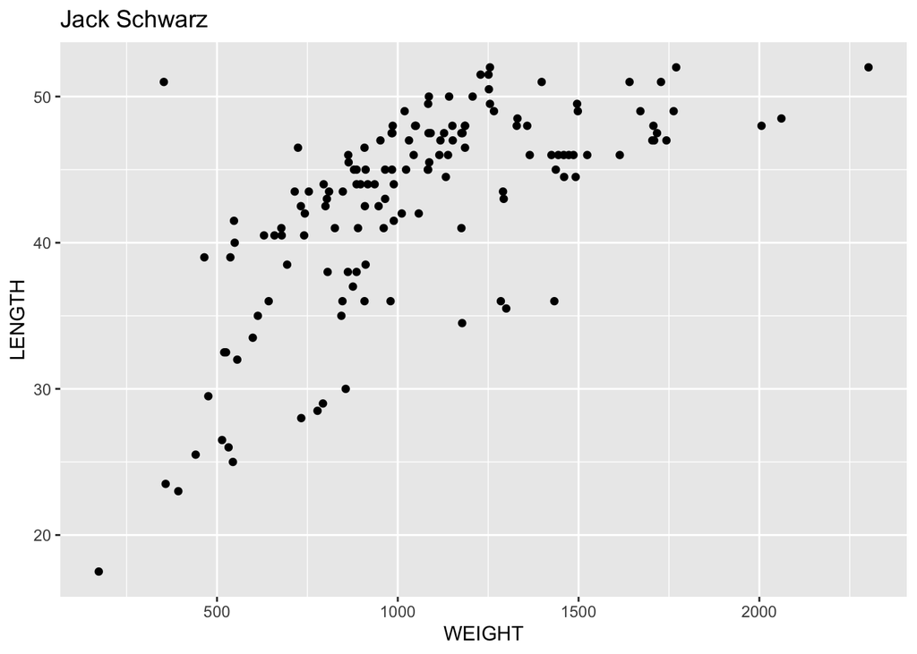

```r
ggplot(ddt, aes(x=WEIGHT, y=LENGTH)) + geom_point() + ggtitle("Jack Schwarz")
```

4. The last value of v=1:20 is 1.0

```r
v=1:20
v/20
```

```
##  [1] 0.05 0.10 0.15 0.20 0.25 0.30 0.35 0.40 0.45 0.50 0.55 0.60 0.65 0.70 0.75
## [16] 0.80 0.85 0.90 0.95 1.00
```

## Task 4

1. Below is the River Table

```r
rt=with(ddt,table(RIVER))
rt
```

```
## RIVER
## FCM LCM SCM TRM
##   6   6   6 126
```

2. Here is a barplot of the above table

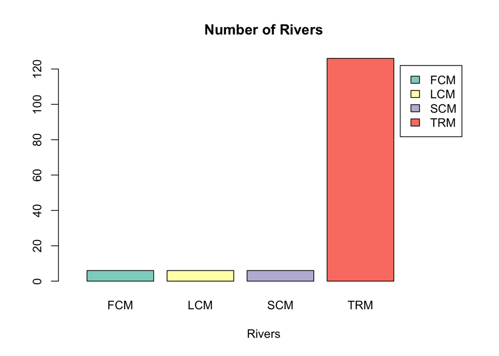

```r
colr = brewer.pal(4, "Set3")
barplot(rt,legend=TRUE, xlim = c(0,5.7),col=colr, xlab="Rivers", main="Number of Rivers")
```

c. Below is a cross table of Rivers and Species of Fish

```r
dtable = with(ddt,table(SPECIES,RIVER))
dtable
```

```
##            RIVER
## SPECIES     FCM LCM SCM TRM
##   CCATFISH    6   6   6  78
##   LMBASS      0   0   0  12
##   SMBUFFALO   0   0   0  36
```

4. Here is the barplot of the above table

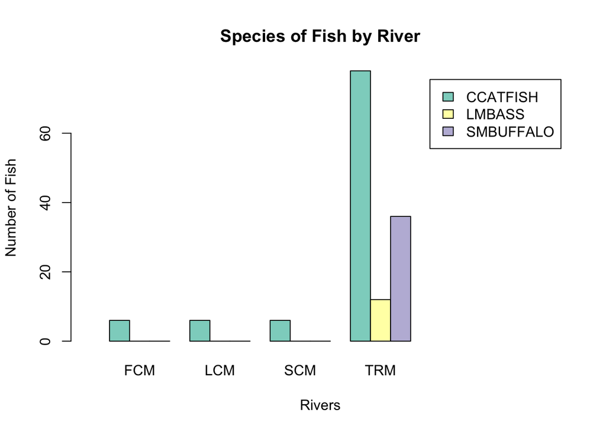

```r
colr2= brewer.pal(3, "Set3")
barplot(dtable,beside=TRUE,legend=TRUE,col=colr2, xlab="Rivers", ylab="Number of Fish",main="Species of Fish by River",xlim = c(0,23))
```

## Task 5

1. Below is the Species pie chart.

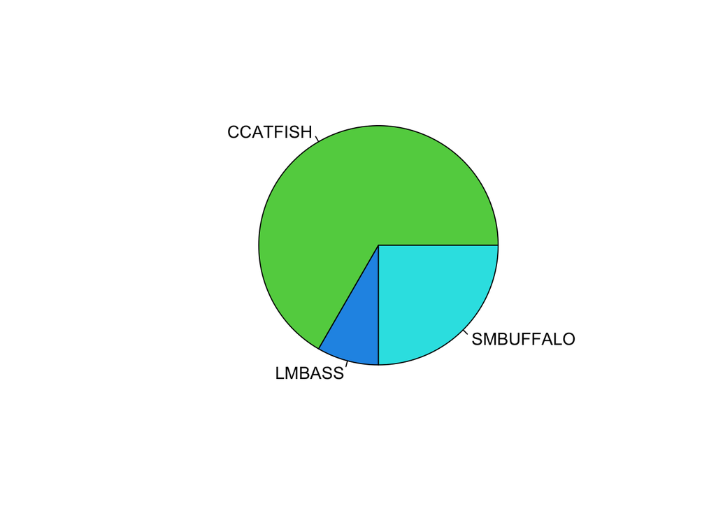

```r
sp=with(ddt,table(SPECIES))
pie(sp,col=3:7)
```

2. Here is the River Pie Chart

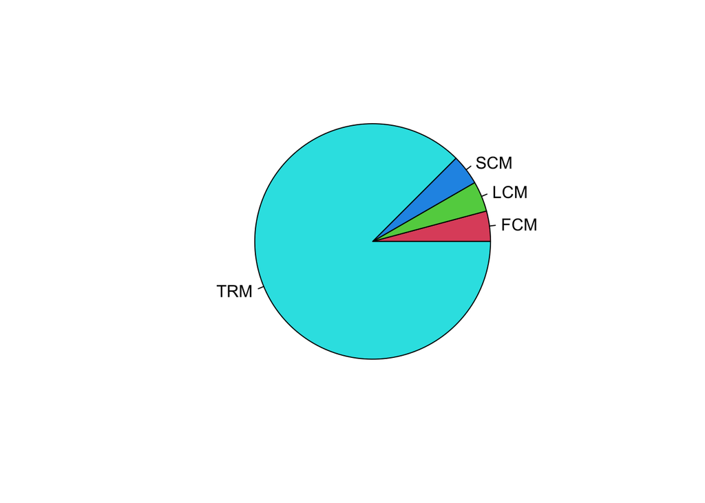

```r
pie(rt, col=2:6)
```

## Task 6

Below are a, b, c. These are the boxplots of DDT, Weight, and Length.

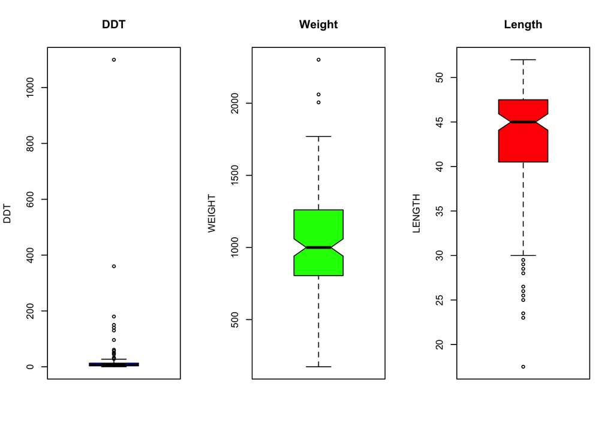

```r
layout(matrix(c(1,2,3),nr=1,nc=3))
with(ddt,boxplot(DDT,ylab="DDT",col="Blue", main="DDT",notch=TRUE))
with(ddt,boxplot(WEIGHT,ylab="WEIGHT",col="Green", main="Weight",notch=TRUE))
with(ddt,boxplot(LENGTH,ylab="LENGTH",col="Red", main="Length",notch=TRUE))
```

## Task 7

1. Here is the coplot of Length Vs Weight given River

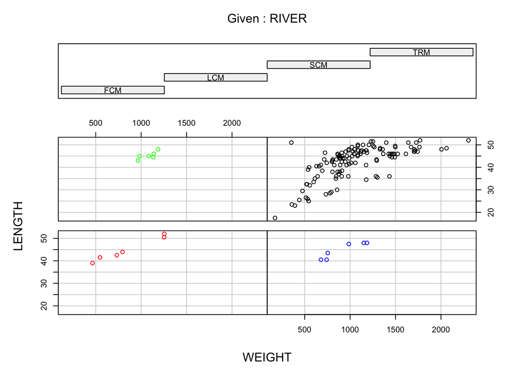

```r
rivcol=with(ddt, ifelse(RIVER=="FCM","Red",
                        ifelse(RIVER=="LCM","Blue",
                               ifelse(RIVER=="SCM","Green","Black"))))

coplot(LENGTH~WEIGHT|RIVER,data=ddt,col=rivcol)
```

2. Here is the coplot of DDT Vs Weight given Species

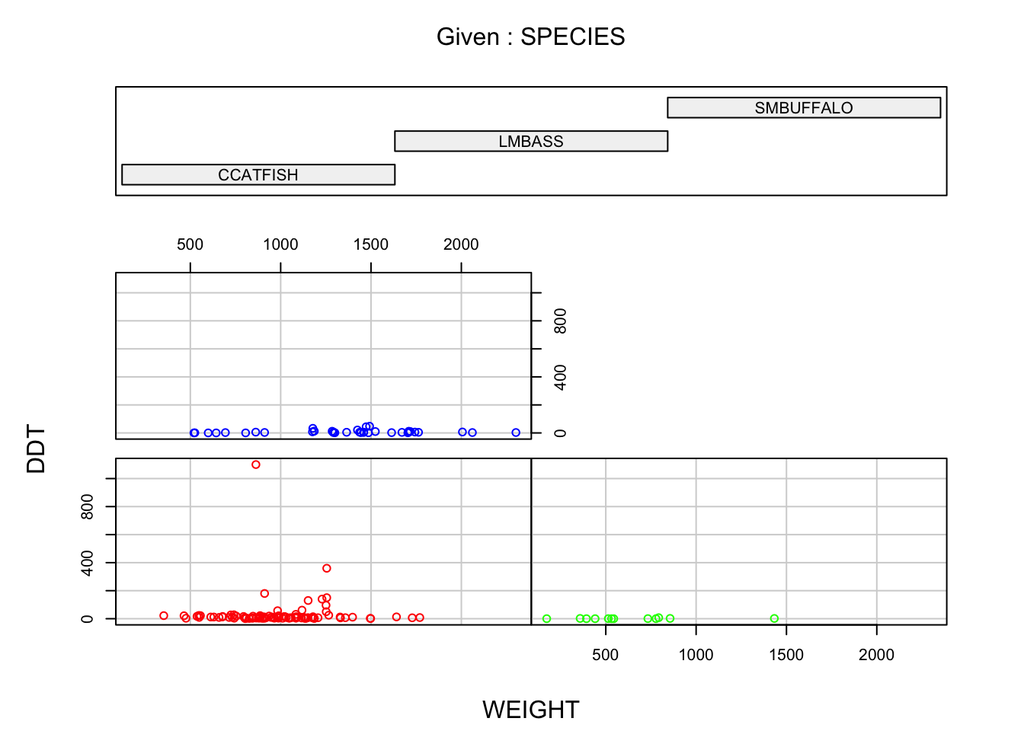

```r
fishcol=with(ddt,ifelse(SPECIES=="CCATFISH","Red",
                        ifelse(SPECIES=="SMBUFFALO","Blue","Green")))

coplot(DDT~WEIGHT|SPECIES,data=ddt,col=fishcol)
```

## Task 8

1. Here is the ggplot Boxplot

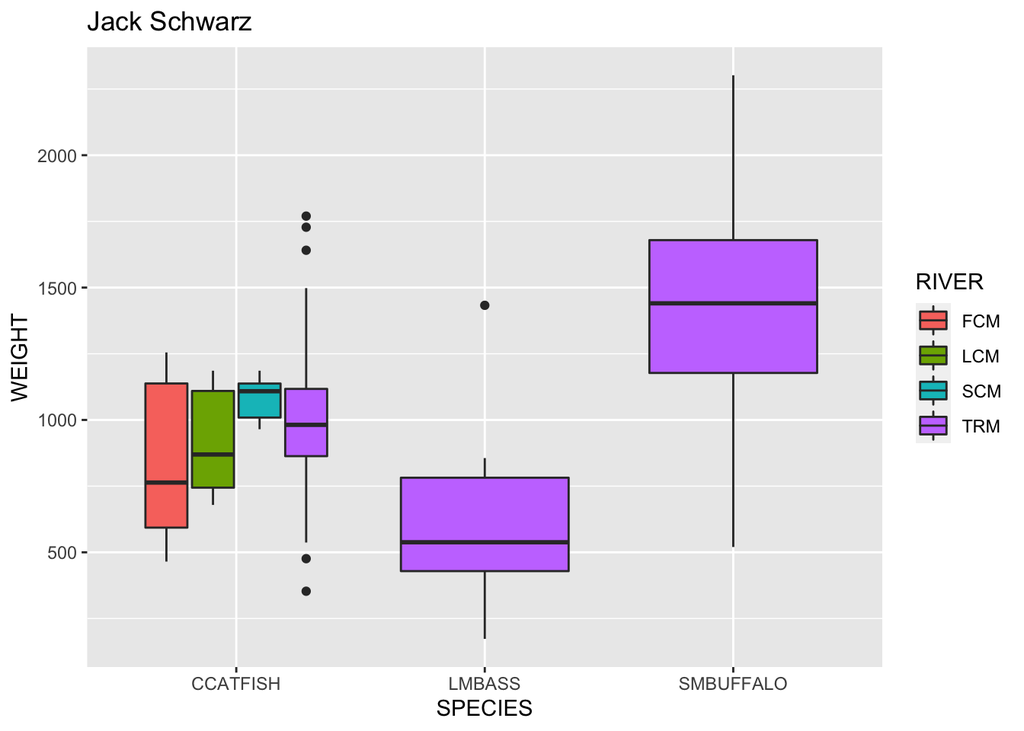

```r
ggplot(ddt, aes(x=SPECIES, y=WEIGHT, fill=RIVER)) +
  geom_boxplot() + ggtitle("Jack Schwarz")
```

2. Here is the ggplot Violin Plot

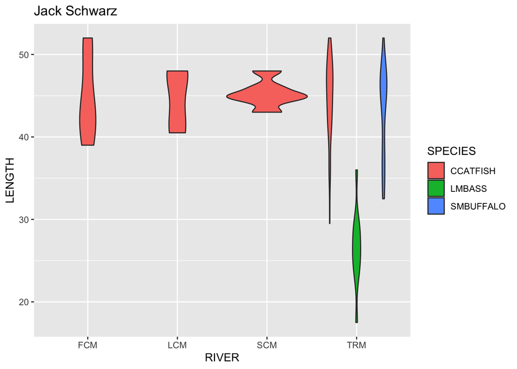

```r
ggplot(ddt, aes(x=RIVER, y=LENGTH, fill=SPECIES)) +
  geom_violin() + ggtitle("Jack Schwarz")
```

3. Here is the ggplot Scatter Plot

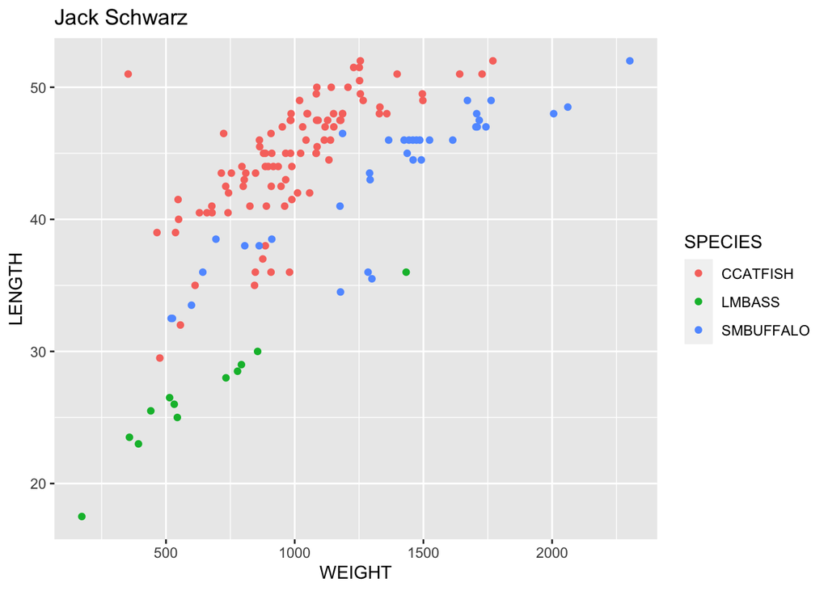

```r
ggplot(ddt, aes(x=WEIGHT, y=LENGTH, fill=SPECIES, color=SPECIES)) +
  geom_point() + ggtitle("Jack Schwarz")
```